# How do College Students View and Listen to Music?

Julia Van Boening

### Introduction

One thing I like to do in my free time is listen to music. This interest of mine started to develop in college as I noticed so many students listen to music while they study or walk to class. When and where I listen to music, what music I listen to, and what playlists I should create so my friends can see what I listen to has evolved over the course of my three years at California Polytechnic State University - San Luis Obispo. Music and streaming platforms have become another form of social media, and part of my generation’s identity. Therefore, I wanted to create a questionnaire to see how college students view and listen to music.

### Data

I decided to use Google Forms as it is cost effective, easy to use and read, fast to create, and every respondent is familiar with it. Even though these responses are random and anonymous, I achieved the data by putting a link in my Instagram bio and asking my followers to take it from my Instagram Story. Therefore, there is bias in this analysis as most of the respondents probably go to Cal Poly, and they had to see my story and follow me in order to take the questionnaire. After eliminating 1 respondent who was not in college, the data has 30 observations, which is a large enough sample size to use when looking for statistical significance. The last 2 questions of the questionnaire are for my own personal enjoyment and curiosity as Post Malone is one of my favorite artists.

#### Bar Charts

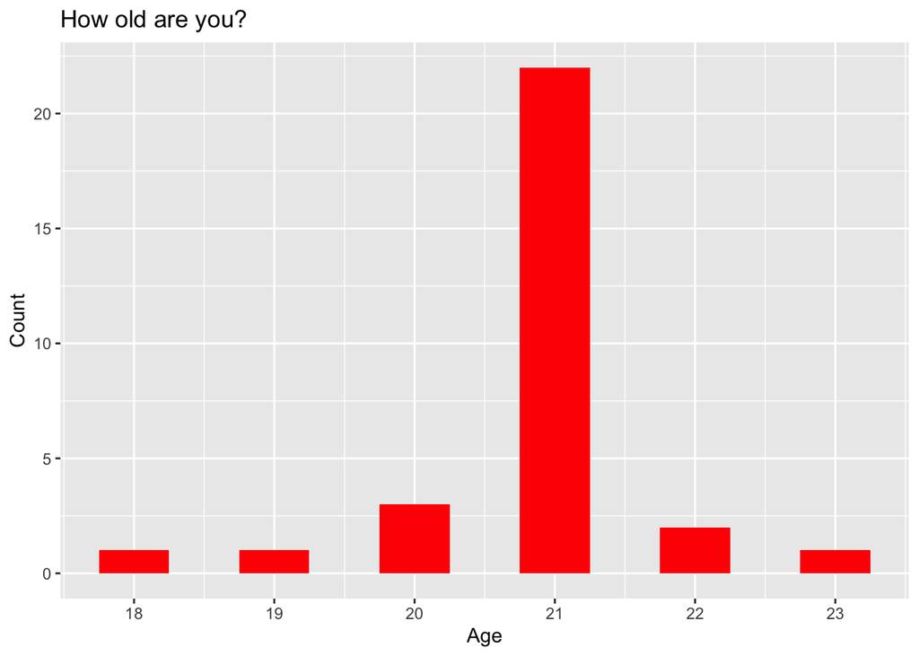

| age | 18 | 19 | 20 | 21 | 22 | 23 |
| --- | --- | --- | --- | --- | --- | --- |
| n | 1 | 1 | 3 | 22 | 2 | 1 |

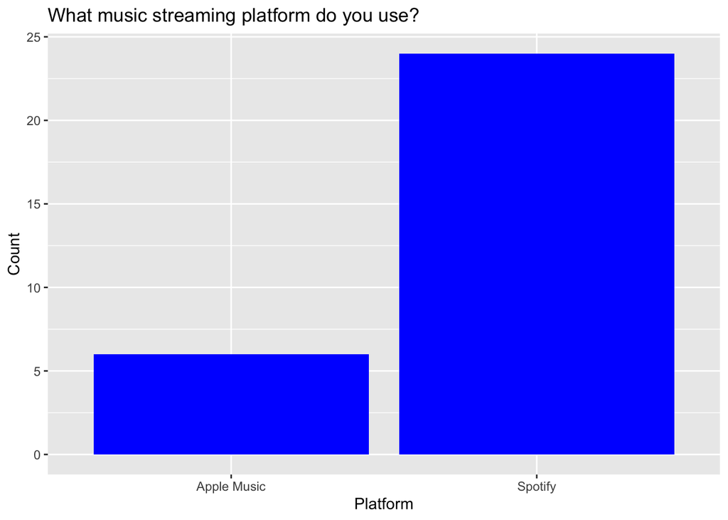

| platform | Apple Music | Spotify |
| --- | --- | --- |
| n | 6 | 24 |

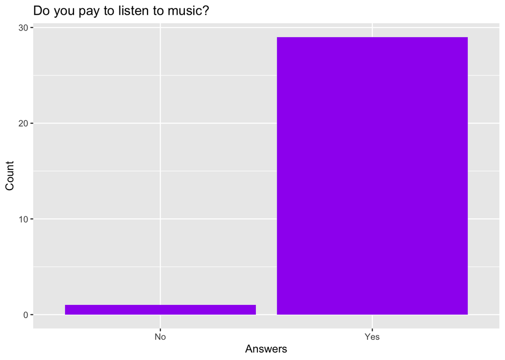

| pay | No | Yes |
| --- | --- | --- |
| n | 1 | 29 |

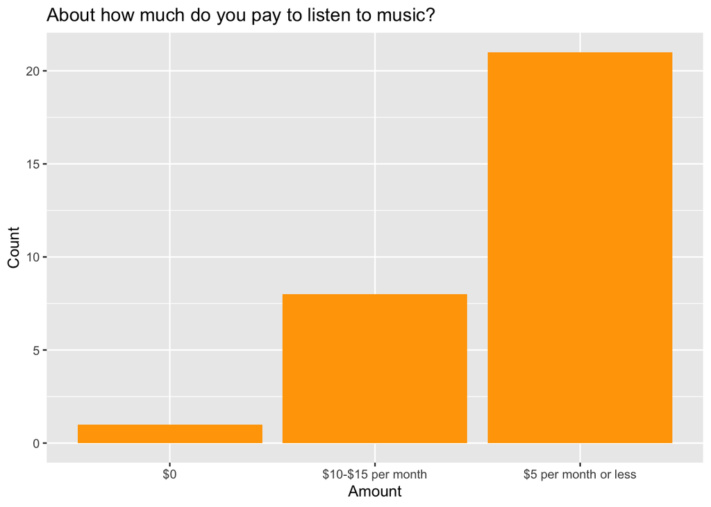

| money | $0 | $10-$15 per month | $5 per month or less |
| --- | --- | --- | --- |
| n | 1 | 8 | 21 |

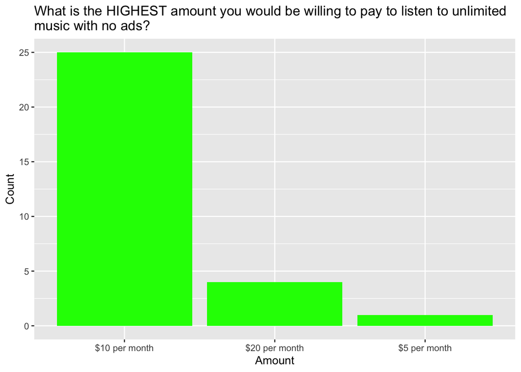

| highest | $10 per month | $20 per month | $5 per month |
| --- | --- | --- | --- |
| n | 25 | 4 | 1 |

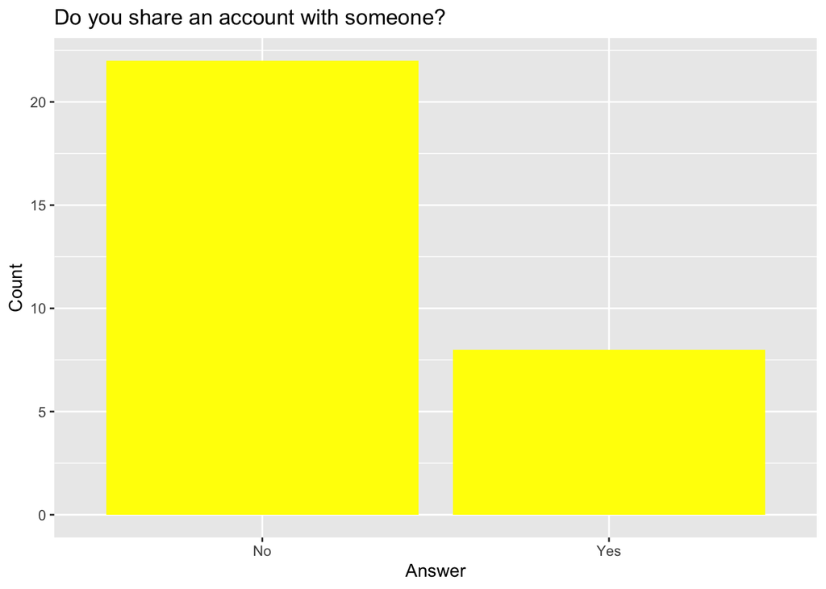

| share | No | Yes |
| --- | --- | --- |
| n | 22 | 8 |

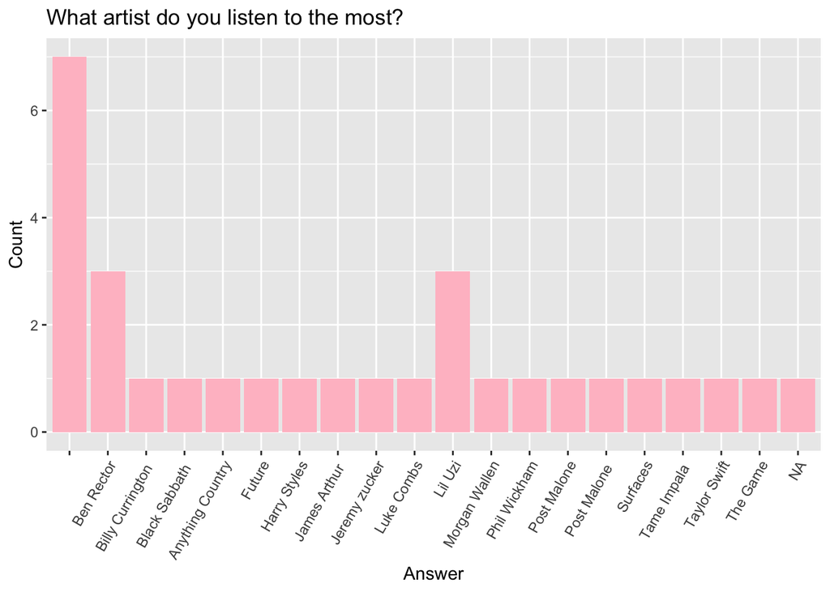

| artist |  | Ben Rector | Billy Currington | Black Sabbath | Anything Country | Future | Harry Styles | James Arthur | Jeremy zucker | Luke Combs | Lil Uzi | Morgan Wallen | Phil Wickham | Post Malone | Post Malone | Surfaces | Tame Impala | Taylor Swift | The Game | NA |
| --- | --- | --- | --- | --- | --- | --- | --- | --- | --- | --- | --- | --- | --- | --- | --- | --- | --- | --- | --- | --- |
| n | 7 | 3 | 1 | 1 | 1 | 1 | 1 | 1 | 1 | 1 | 3 | 1 | 1 | 1 | 1 | 1 | 1 | 1 | 1 | 1 |

*note: 7 people did not answer, + the 1 NA*

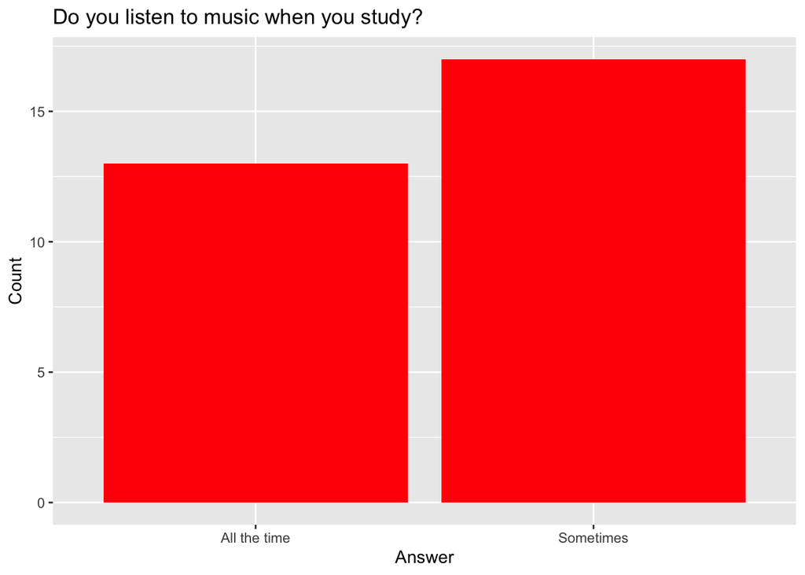

| study | All the time | Sometimes |
| --- | --- | --- |
| n | 13 | 17 |

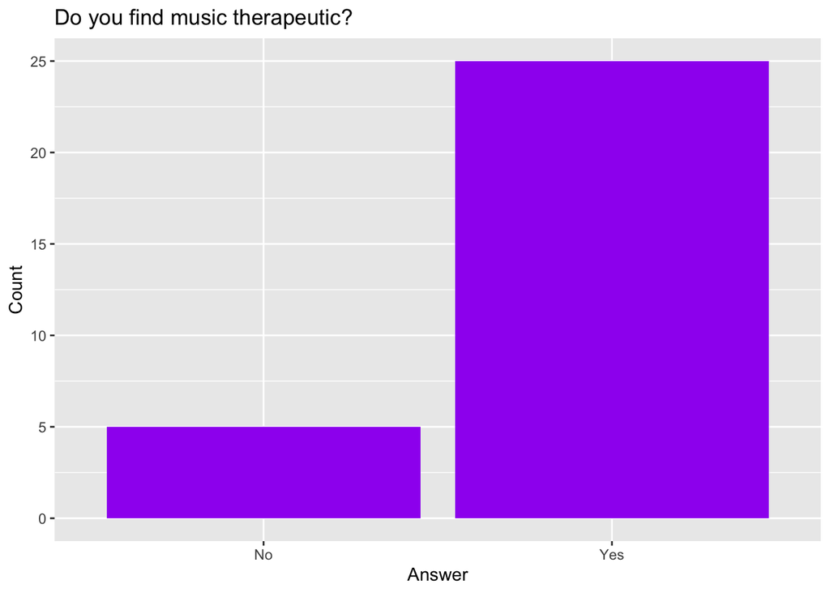

| therapy | No | Yes |
| --- | --- | --- |
| n | 5 | 25 |

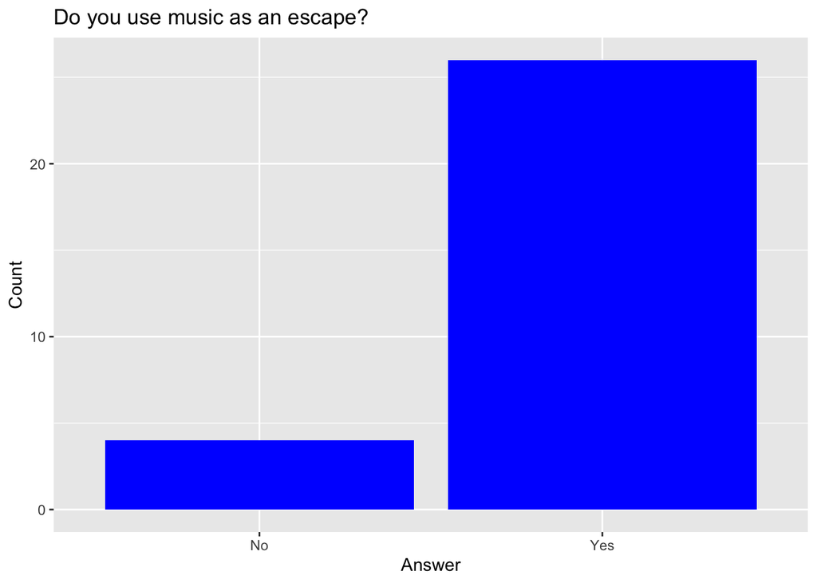

| escape | No | Yes |
| --- | --- | --- |
| n | 4 | 26 |

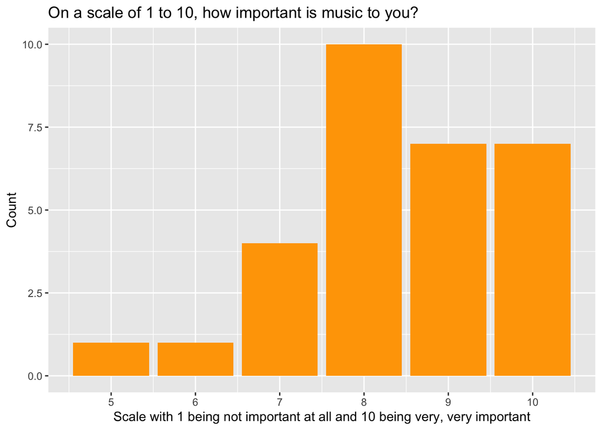

| important | 5 | 6 | 7 | 8 | 9 | 10 |
| --- | --- | --- | --- | --- | --- | --- |
| n | 1 | 1 | 4 | 10 | 7 | 7 |

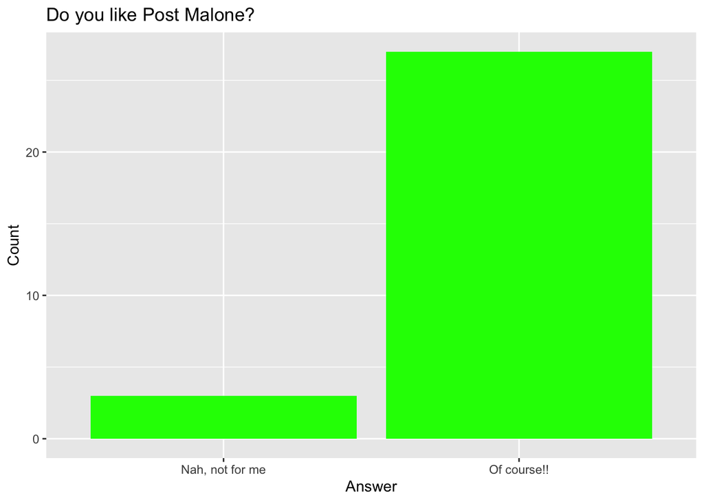

| posty | Nah, not for me | Of course!! |
| --- | --- | --- |
| n | 3 | 27 |

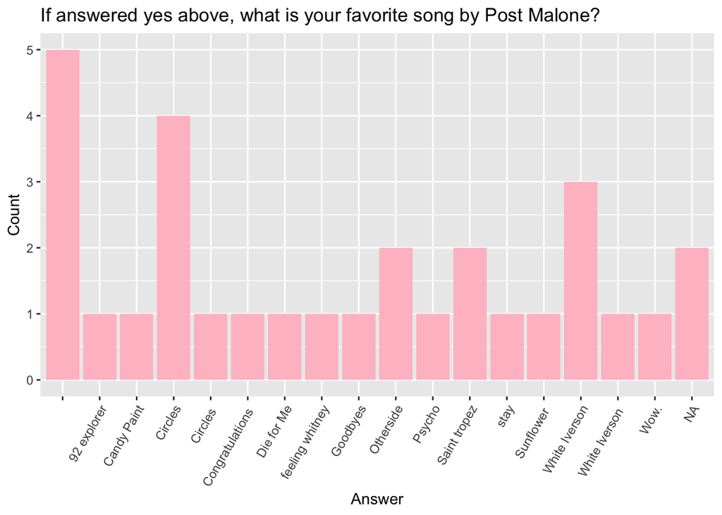

| malone |  | 92 explorer | Candy Paint | Circles | Circles | Congratulations | Die for Me | feeling whitney | Goodbyes | Otherside | Psycho | Saint tropez | stay | Sunflower | White Iverson | White Iverson | Wow. | NA |
| --- | --- | --- | --- | --- | --- | --- | --- | --- | --- | --- | --- | --- | --- | --- | --- | --- | --- | --- |
| n | 5 | 1 | 1 | 4 | 1 | 1 | 1 | 1 | 1 | 2 | 1 | 2 | 1 | 1 | 3 | 1 | 1 | 2 |

*note: 5 people did not respond, + the 2 NA*

#### Multi-Variable Linear Regression Models

Before using a regression model, you have to ensure that it is statistically significant.

The summary statistics tells us a number of things. One of them is the model p-Value (bottom last line) and the p-value of individual predictor variables (extreme right column under ‘Coefficients’). The p-values are very important because we can consider a linear model to be statistically significant only when both of these p-values are less than the pre-determined statistical significance level, which is ideally 0.05. This is visually interpreted by the significance stars at the end of the row. The more stars beside the variable’s p-value, the more significant the variable.

*Linear Regression Model Predicting Music Platform Used*

```
##
## Call:
## lm(formula = platform ~ age + pay + money + highest + share +
##     study + therapy + escape + important, data = new_data)
##
## Residuals:
##      Min       1Q   Median       3Q      Max
## -0.60009 -0.09185  0.00000  0.14985  0.40880
##
## Coefficients: (1 not defined because of singularities)
##                         Estimate Std. Error t value Pr(>|t|)
## (Intercept)            -2.704031   1.565408  -1.727  0.10032
## age                     0.159595   0.069092   2.310  0.03229 *
## payNo                   0.342056   0.324653   1.054  0.30528
## money$0                       NA         NA      NA       NA
## money$10-$15 per month -0.310084   0.149456  -2.075  0.05184 .
## highest$20 per month    0.006886   0.168465   0.041  0.96782
## highest$5 per month     0.158489   0.316900   0.500  0.62273
## shareNo                -0.318974   0.156879  -2.033  0.05624 .
## studySometimes         -0.578058   0.150046  -3.853  0.00107 **
## therapyNo               0.653603   0.172993   3.778  0.00127 **
## escapeNo               -0.110992   0.189932  -0.584  0.56584
## important               0.084078   0.048073   1.749  0.09643 .
## ---
## Signif. codes:  0 '***' 0.001 '**' 0.01 '*' 0.05 '.' 0.1 ' ' 1
##
## Residual standard error: 0.2872 on 19 degrees of freedom
## Multiple R-squared:  0.6734, Adjusted R-squared:  0.5016
## F-statistic: 3.918 on 10 and 19 DF,  p-value: 0.0051
```

The model has a significant p-value of 0.0051, and the predictor variables that also have a significant p-value are age, study, and therapy. This means there is a relationship between the music platform someone uses and their age, if they listen to music when they study, and if they find music theraputic.

*Linear Regression Model Predicting if Someone Listens to Music when they Study*

```
##
## Call:
## lm(formula = study ~ age + pay + money + highest + share + platform +
##     therapy + escape + important, data = new_data1)
##
## Residuals:
##      Min       1Q   Median       3Q      Max
## -0.49043 -0.17422  0.02945  0.14467  0.64699
##
## Coefficients: (1 not defined because of singularities)
##                        Estimate Std. Error t value Pr(>|t|)
## (Intercept)            -2.25126    1.97414  -1.140  0.26830
## age                     0.12234    0.08507   1.438  0.16669
## payNo                   0.30592    0.37615   0.813  0.42612
## money$0                      NA         NA      NA       NA
## money$10-$15 per month -0.46152    0.15732  -2.934  0.00852 **
## highest$20 per month    0.06883    0.19236   0.358  0.72444
## highest$5 per month    -0.12318    0.36434  -0.338  0.73901
## shareNo                -0.50231    0.16140  -3.112  0.00574 **
## platformApple Music     0.75869    0.19693   3.853  0.00107 **
## therapyNo               0.69596    0.20807   3.345  0.00340 **
## escapeNo                0.16565    0.21623   0.766  0.45305
## important               0.05375    0.05805   0.926  0.36607
## ---
## Signif. codes:  0 '***' 0.001 '**' 0.01 '*' 0.05 '.' 0.1 ' ' 1
##
## Residual standard error: 0.3291 on 19 degrees of freedom
## Multiple R-squared:  0.7207, Adjusted R-squared:  0.5737
## F-statistic: 4.903 on 10 and 19 DF,  p-value: 0.001456
```

The model has a significant p-value of 0.001456, and the predictor variables that also have a significant p-value are money, share, platform, and therapy. This means there is a relationship between if someone listens to music when they study and how much money they pay to listen to music, if they share their account, the music platform they use, and if they find music theraputic.

*Linear Regression Model Predicting if Someone Finds Music Therapeutic*

```
##
## Call:
## lm(formula = therapy ~ age + pay + money + highest + share +
##     platform + study + escape + important, data = new_data2)
##
## Residuals:
##      Min       1Q   Median       3Q      Max
## -0.41833 -0.16394  0.04008  0.13454  0.44448
##
## Coefficients: (1 not defined because of singularities)
##                        Estimate Std. Error t value Pr(>|t|)
## (Intercept)            -1.62841    1.67999  -0.969  0.34457
## age                     0.10623    0.07447   1.426  0.16998
## payNo                   0.34145    0.32541   1.049  0.30721
## money$0                      NA         NA      NA       NA
## money$10-$15 per month -0.14887    0.16232  -0.917  0.37055
## highest$20 per month    0.07222    0.16801   0.430  0.67216
## highest$5 per month     0.18640    0.31678   0.588  0.56318
## shareNo                -0.35532    0.15313  -2.320  0.03160 *
## platformApple Music     0.65636    0.17372   3.778  0.00127 **
## studySometimes         -0.53250    0.15920  -3.345  0.00340 **
## escapeNo               -0.13327    0.18959  -0.703  0.49060
## important               0.08410    0.04819   1.745  0.09711 .
## ---
## Signif. codes:  0 '***' 0.001 '**' 0.01 '*' 0.05 '.' 0.1 ' ' 1
##
## Residual standard error: 0.2878 on 19 degrees of freedom
## Multiple R-squared:  0.6222, Adjusted R-squared:  0.4234
## F-statistic: 3.129 on 10 and 19 DF,  p-value: 0.01559
```

The model has a significant p-value of 0.01559, and the predictor variables that also have a significant p-value are share, platform, and study. This means there is a relationship between if someone finds music theraputic and if they share their account, the music platform they use, and if they listen to music when they study.

*Linear Regression Model Predicting if Someone uses Music as an Escape*

```
##
## Call:
## lm(formula = escape ~ age + pay + money + highest + share + platform +
##     study + therapy + important, data = new_data3)
##
## Residuals:
##      Min       1Q   Median       3Q      Max
## -0.65370 -0.09210  0.00867  0.13416  0.51122
##
## Coefficients: (1 not defined because of singularities)
##                        Estimate Std. Error t value Pr(>|t|)
## (Intercept)             1.77523    2.12495   0.835    0.414
## age                    -0.04809    0.09296  -0.517    0.611
## payNo                   0.05094    0.39969   0.127    0.900
## money$0                      NA         NA      NA       NA
## money$10-$15 per month -0.14102    0.19550  -0.721    0.479
## highest$20 per month   -0.00865    0.20168  -0.043    0.966
## highest$5 per month    -0.04175    0.38175  -0.109    0.914
## shareNo                -0.18837    0.20268  -0.929    0.364
## platformApple Music    -0.15907    0.27221  -0.584    0.566
## studySometimes         -0.18088    0.23612  -0.766    0.453
## therapyNo              -0.19021    0.27058  -0.703    0.491
## important               0.05209    0.06085   0.856    0.403
##
## Residual standard error: 0.3439 on 19 degrees of freedom
## Multiple R-squared:  0.3519, Adjusted R-squared:  0.01086
## F-statistic: 1.032 on 10 and 19 DF,  p-value: 0.4548
```

This model does NOT have a significant p-value meaning using music as an escape is not predicted by anything.

*Linear Regression Model Predicting how Important Music is to Someone*

```
##
## Call:
## lm(formula = important ~ age + pay + money + highest + share +
##     platform + study + therapy + escape, data = data)
##
## Residuals:
##      Min       1Q   Median       3Q      Max
## -2.63208 -0.57838  0.05319  0.73659  2.20411
##
## Coefficients: (1 not defined because of singularities)
##                        Estimate Std. Error t value Pr(>|t|)
## (Intercept)             14.9165     7.1080   2.099   0.0495 *
## age                     -0.3172     0.3386  -0.937   0.3607
## payNo                   -2.0594     1.4018  -1.469   0.1582
## money$0                      NA         NA      NA       NA
## money$10-$15 per month   0.3858     0.7277   0.530   0.6022
## highest$20 per month    -0.3082     0.7428  -0.415   0.6829
## highest$5 per month     -1.1034     1.3899  -0.794   0.4371
## shareNo                  0.5302     0.7570   0.700   0.4922
## platformApple Music     -1.6493     0.9430  -1.749   0.0964 .
## studySometimes           0.8034     0.8676   0.926   0.3661
## therapyNo               -1.6427     0.9413  -1.745   0.0971 .
## escapeNo                -0.7129     0.8328  -0.856   0.4026
## ---
## Signif. codes:  0 '***' 0.001 '**' 0.01 '*' 0.05 '.' 0.1 ' ' 1
##
## Residual standard error: 1.272 on 19 degrees of freedom
## Multiple R-squared:  0.3485, Adjusted R-squared:  0.005666
## F-statistic: 1.017 on 10 and 19 DF,  p-value: 0.4654
```

This model does NOT have a significant p-value meaning how important music is to someone is not predicted by anything.

*Linear Regression Model Predicting how much Money Someone Pays to Listen to Music*

```
##
## Call:
## lm(formula = money ~ age + pay + escape + highest + share + platform +
##     study + therapy + important, data = new_data4)
##
## Residuals:
##      Min       1Q   Median       3Q      Max
## -0.60945 -0.18874  0.01917  0.25588  0.46196
##
## Coefficients:
##                       Estimate Std. Error t value Pr(>|t|)
## (Intercept)           0.436511   2.465347   0.177  0.86134
## age                   0.003157   0.108375   0.029  0.97707
## payNo                -0.913844   0.462508  -1.976  0.06288 .
## escapeNo             -0.189021   0.262040  -0.721  0.47948
## highest$20 per month  0.112722   0.232068   0.486  0.63271
## highest$5 per month   0.355929   0.434502   0.819  0.42285
## shareNo               0.446674   0.216944   2.059  0.05348 .
## platformApple Music  -0.595679   0.287108  -2.075  0.05184 .
## studySometimes        0.675509   0.230257   2.934  0.00852 **
## therapyNo            -0.284785   0.310505  -0.917  0.37055
## important            -0.037781   0.071268  -0.530  0.60217
## ---
## Signif. codes:  0 '***' 0.001 '**' 0.01 '*' 0.05 '.' 0.1 ' ' 1
##
## Residual standard error: 0.3981 on 19 degrees of freedom
## Multiple R-squared:  0.522,  Adjusted R-squared:  0.2705
## F-statistic: 2.075 on 10 and 19 DF,  p-value: 0.08202
```

This model does NOT have a significant p-value meaning how much money someone pays to listen to music is not predicted by anything.

*Linear Regression Model Predicting if Someone Shares their Account*

```
##
## Call:
## lm(formula = share ~ age + pay + escape + highest + money + platform +
##     study + therapy + important, data = new_data5)
##
## Residuals:
##     Min      1Q  Median      3Q     Max
## -0.6431 -0.1166  0.0000  0.2110  0.5732
##
## Coefficients: (1 not defined because of singularities)
##                         Estimate Std. Error t value Pr(>|t|)
## (Intercept)             0.501315   2.357794   0.213  0.83389
## age                    -0.002654   0.103627  -0.026  0.97984
## payNo                   0.214487   0.439904   0.488  0.63143
## escapeNo               -0.230848   0.248383  -0.929  0.36434
## highest$20 per month   -0.216197   0.217695  -0.993  0.33313
## highest$5 per month    -0.068500   0.422445  -0.162  0.87290
## money$0                       NA         NA      NA       NA
## money$10-$15 per month  0.408390   0.198350   2.059  0.05348 .
## platformApple Music    -0.560238   0.275539  -2.033  0.05624 .
## studySometimes          0.672198   0.215987   3.112  0.00574 **
## therapyNo              -0.621453   0.267817  -2.320  0.03160 *
## important              -0.047468   0.067778  -0.700  0.49220
## ---
## Signif. codes:  0 '***' 0.001 '**' 0.01 '*' 0.05 '.' 0.1 ' ' 1
##
## Residual standard error: 0.3807 on 19 degrees of freedom
## Multiple R-squared:  0.5307, Adjusted R-squared:  0.2837
## F-statistic: 2.149 on 10 and 19 DF,  p-value: 0.07265
```

This model does NOT have a significant p-value meaning sharing an account is not predicted by anything.

*Linear Regression Model Predicting what is the Highest Amount Someone would be willing to Pay to Listen to Unlimited Music with No Ads*

```
##
## Call:
## lm(formula = highest ~ age + pay + escape + share + money + platform +
##     study + therapy + important, data = new_data6)
##
## Residuals:
##     Min      1Q  Median      3Q     Max
## -0.8069 -0.0790  0.1289  0.2265  0.3262
##
## Coefficients: (1 not defined because of singularities)
##                         Estimate Std. Error t value Pr(>|t|)
## (Intercept)             0.691701   2.478079   0.279    0.783
## age                    -0.009603   0.109668  -0.088    0.931
## payNo                   0.194803   0.482239   0.404    0.691
## escapeNo               -0.023461   0.278143  -0.084    0.934
## shareNo                -0.236491   0.245019  -0.965    0.346
## money$0                       NA         NA      NA       NA
## money$10-$15 per month  0.185411   0.235085   0.789    0.440
## platformApple Music     0.081380   0.330928   0.246    0.808
## studySometimes         -0.052587   0.288731  -0.182    0.857
## therapyNo               0.209156   0.328141   0.637    0.531
## important               0.052536   0.073748   0.712    0.484
##
## Residual standard error: 0.417 on 20 degrees of freedom
## Multiple R-squared:  0.1652, Adjusted R-squared:  -0.2105
## F-statistic: 0.4397 on 9 and 20 DF,  p-value: 0.8972
```

This model does NOT have a significant p-value meaning the highest amount someone would be willing to pay to listen to unlimited music with no ads is not predicted by anything.